# Human Resource Analysis

# Multivariate plots

Let’s see how time spend in the company, number of projects and exits relate to one another.

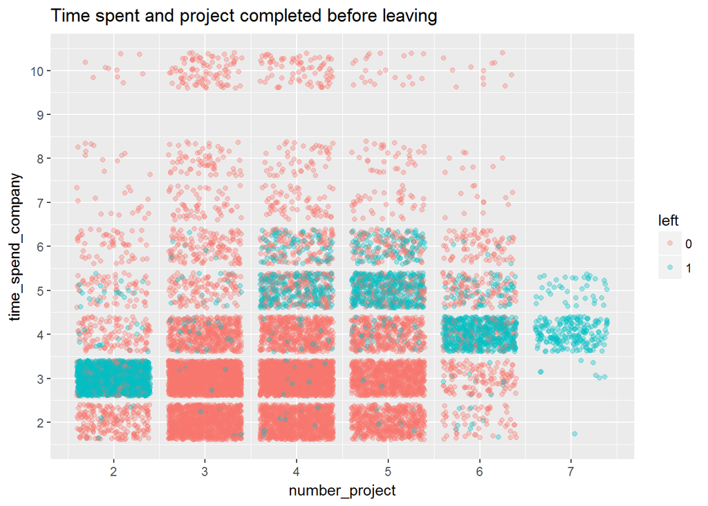

- It can be seen that, most exits of the employees took place in the 3rd year with two projects.
- Then people left in the 4th year with 6 to 7 projects. May be they were feeling overworked.
- There are no exits after spending 7 years.

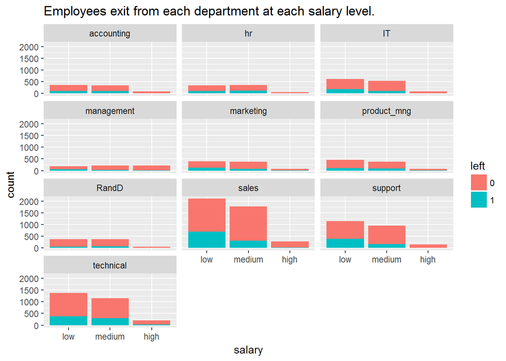

- Looking at the dataset department wise, and considering salary and exit patterns I saw that there are almost equal proportion of exits in each deparment.
- Number of exists is propotional to the number of employees working in that department.
- Highly paid employees are least in number to exit.

```
##
## FALSE  TRUE
##  3552    19
```

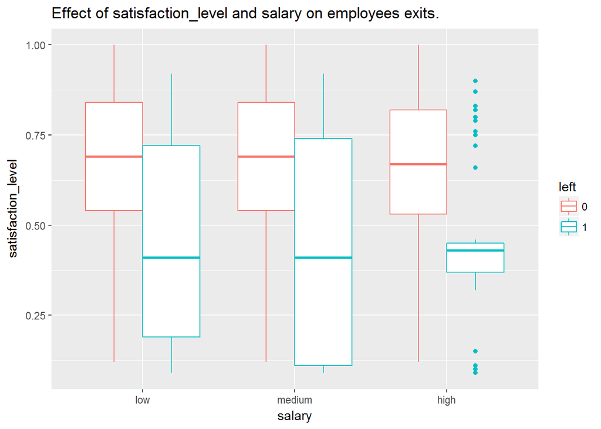

- Considering salary levels, satisfaction_levels and whether one left or not I found that those did not leave have equal distribution of satisfaction level, which is around mean, across all salary levels.
- On the other hand, those who left had median of satiasfaction level below half across all three salary levels.
- High salaried employees had lower satisfaction level for 25th to 75th pencentile of people. The outliers we see had extremely low or extremely high satisfation levels.

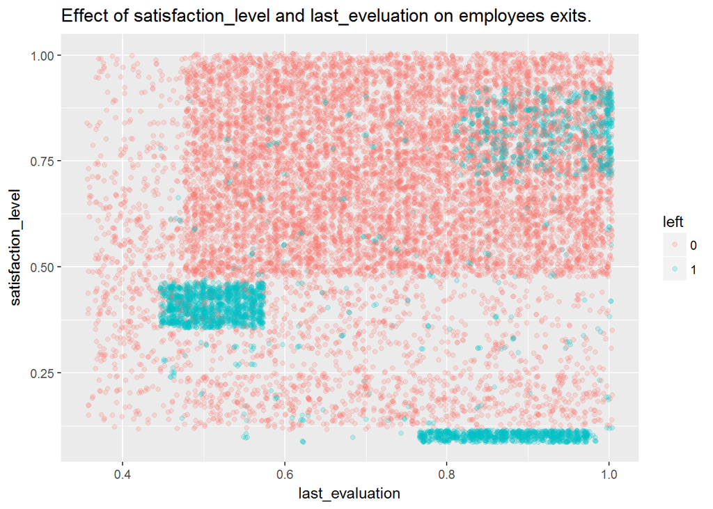

- Some efficient employees with very low satisfaction level and other with high satisfaction level have left job in both scenario.
- A bunch of inefficient employees left jobs having low satisfaction level.

** How many years an employee spends in a company before leaving, given that salary is high, satisfaction level is above 75%, efficiency is above 75% **

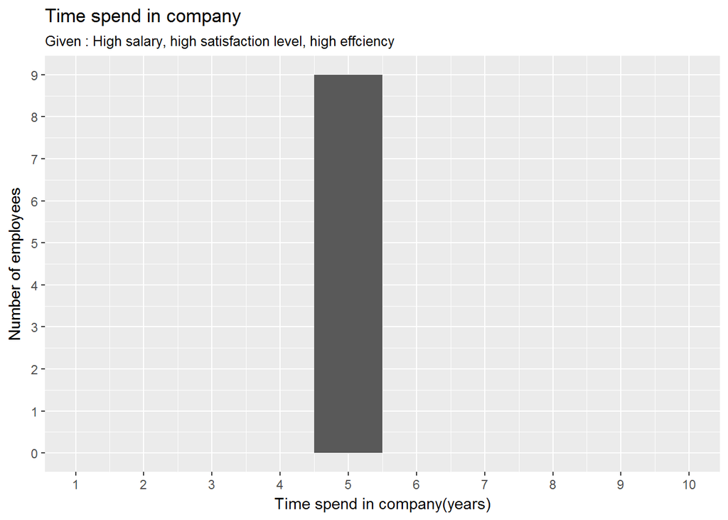

- There are 9 such employees and they all have spent 5 years in the company.

# Multivariate Analysis

### Were there features that strengthened each other in terms of looking at your feature(s) of interest?

In each department, the difference between number of people leaving who work at low and medium salary is not very vast.

between features?

Median of satisfaction across low, mid and high salary levels is almost equal.

People receiving high salary, having more that 75% satisfaction level and scoring more that 75% in last_evaluation have left job after serving the company for 5 years. Surprising, none of them have been promoted in last 5 years. It is possible that they are among the top notch of the company from the beginning.

### Did you create any models with your dataset? Discuss the strengths and limitations of your model.

Yes, I have created a matematical model that predicts possible exits.

**Predicting who are likely to leave.**

Considering the above analysis, we know some of the scenarios which cause people to leave their job.

Using some mathemetical conditions and bringing all the scenarios together,if we find all the conditions at one place we can predict that who are and how many employees likely to leave their jobs.

The conditions I used are:

- left == 0 &
- satisfaction_level < 0.5 &
- salary == “low” | salary ==“medium”) &
- time_spend_company == 3 &
- (daily_work_hour==7 |daily_work_hour==12)&
- (last_evaluation <= 0.5 | last_evaluation>=0.75)&
- number_project == 2

These conditions are found to be true for 201 observations.

The limitation of this prediction is that it does not involves job leaving tendency of highly paid and efficient employees. Only the conditions where exits are more frequent have been taken into account.

```
##
##     0     1
## 14798   201
```

# Final Plots and Summary

### Plot one

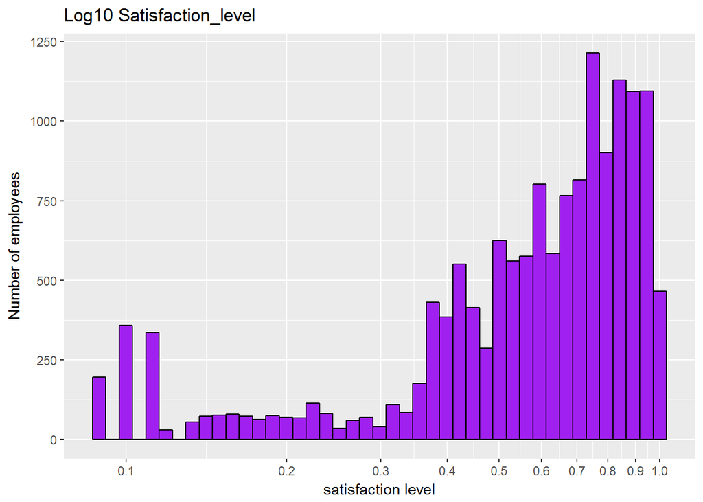

### Plot two

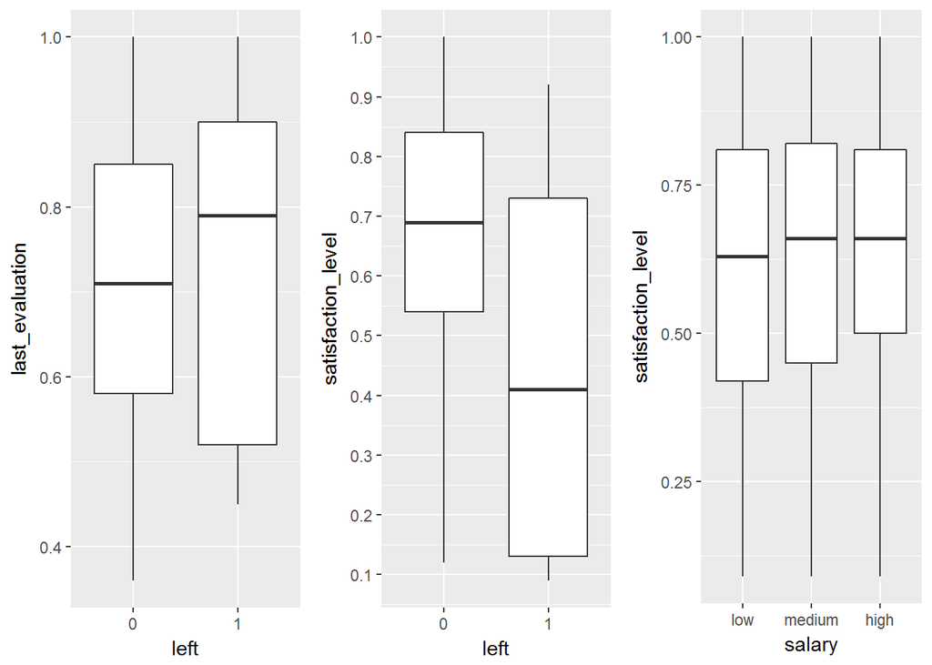

### Description two

Average and high performer are more amongst those who left.

Median of satisfaction level who stayed is above mean, while it is quite low for those who left.

Althoght 1st quartile of satisfaction level is increasing with salary. for each salary level, 50% employees have satisfaction_level above mean.

### Plot three

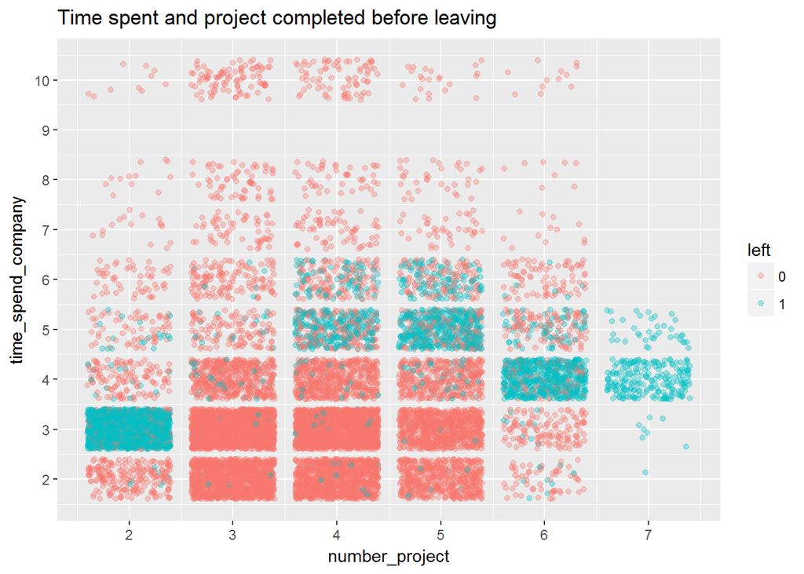

### Description three

It can be seen that, most exits of the employees took place in the 3rd year with two projects.

Then people left in the 4th year with 6 to 7 projects. May be they were feeling overworked.

There are no exits after spending 7 years.

# Reflection

- The human resource dataset contains 14999 observations and 10 variables originally. I was facsinated to know what makes employees to make a big decision of leavinf or changing their jobs. I started with making some adjustment to the dataset to simplify the analysis and to get better results. I factored and ordered some variables like department, salary, left, promotion_last_5years etc, so that summaries could give informative results.
- Then I derived daily_working_hour variable from average_monthly_hours. I went on with analysing each varible separately to see the variation within each variable.
- I found that more than 50% of employee are moderately satisfied. Not even low performers but high performers are also leaving jobs. Most people leave job after completing 3 years in the same company.
- Very low percentage of employees were promoted in last 5 years.
- Moving on, I analysed what variations any two variables show with repect to each other.The both negative and positive correlations are observed between many variable but some how they are not very strong. With respect to left: satisfaction_level, work_accident, and promotion_last_5years are negatively correlated while others are positively correlated(with respect to ‘left’). Satisfaction_level and promotions as well as number_project and daily_working_hours are positively correlated.
- I had a presumption that satisfaction_level and left would influenced each other very strongly but I found this idea collapsing during this analysis.
- Lastly I examined the multiple variables altogether and found some interesting facts that number of exits is propotional to the number of employees working in that department.Highly paid employees are least in number to leave.Some efficient employees with very low satisfaction level and other with high satisfaction level have left job in both the scenarios.
- I also answered some interesting questions like: How many years an employee spends in a company before leaving, given that salary is high, satisfaction level is above 75%, efficiency is above 75% ? Answer is- 5years.
- I created a mathematical model that predicts possible future exits from the company. Certain conditions/criteria are found to be true for 201 observations.
- The limitation of this prediction is that it does not involves job leaving tendency of highly paid employees. Only the conditions where exits are more frequent have been taken into account.Limited knowledge about the source of the dataset is also a drawback.
- I faced some difficulty while calculating correlation between variables because some variables were numerical while other were factored or ordered. I converted them accordingly.
- I found success in deriving new veriables, answering some question that came to my mind and also in predicted the exits that are most likely in near future.
- There is a scope for future analysis in this dataset. I would like to create a stronger model to predict the number of exits more accurately.
- I would like to find out why some top performers receiving high salary have satisfaction_level as low as 0.09.
- It would have been better if there were more features into picture which affects the satisfaction level like working conditions, interaction within the hierarchy of supervisiors, amenitites and allowances.